# KUSHAGRA AGARWAL 2018113012

## Task-6: Random walk with a trap

At $x=M$, random walker is trapped, i.e. imangine that $x=M$ is the location of jail, where once the 'drunk' random walker reaches, is trapped for ever.

Let $y_M(t)$ is the probabilty that a trapped random walker at time $t$ in a trap located at $x=M$, given that starting point is $x=0$ at $t=0$.

Compute $y_M(t)$ by generating a sample of random walks. Comment.

```python
def createwalktrap(M):
    '''This function generates a random walk from 0 to whatever value it can get to using the formula
    X(t)=X(t-1)+(-1/1)
    To get the random nature of the plot i used the random.randint function for the range 0-9
    if the value is >4 it returns 1 or else -1.
    In this there is an added condition that if the value of the plot reaches a certain value M then the value wont change further
    We say that there is a trap set at the position M and the walk gets trapped there

    Input type- None

    Output- A graph starting from 0 and depicting a random walk with a trap set at M according to tne aforesaid parameters
    '''
    walk=[0.0]*100
    walk[0]=0
    for i in range(1,100):
        b=random.randint(0,9)
        if(b>4):
            c=1
        else:
            c=-1
        if(walk[i-1]==M): #if the T is stuck we fill all the remaining with the current value
            walk[i]=walk[i-1]
        else:      #if the T is not yet stuck we fill the walk as earlier
            walk[i]=walk[i-1]+c
    plt.plot(range(0,100),walk)
    plt.title("Walk with a Trap")
    plt.xlabel("T")
    plt.ylabel("X(T)")
```

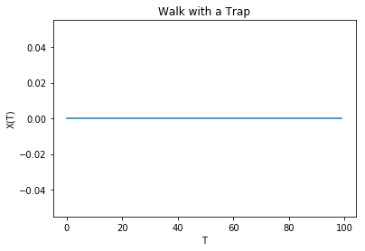

```python
createwalktrap(0)
```

Interpretation:

Because the trap was at 0 so the graph never moved forward as T=0 got trapped

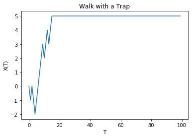

```python
createwalktrap(5)
```

Interpretation:

The walk went through some +1 and -1 to get to 5 and once it did it got stuck as the trap was at 5

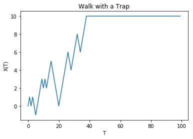

```python
createwalktrap(10)
```

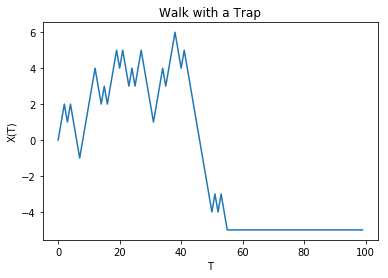

```python
createwalktrap(-5)
```

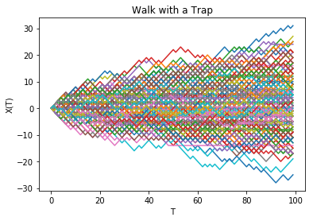

```python
for i in range(-100,100):
    createwalktrap(i)
```

```python
def createwalktrap1(M):
    '''This function generates a random walk from 0 to whatever value it can get to using the formula
    X(t)=X(t-1)+(-1/1)
    To get the random nature of the plot i used the random.randint function for the range 0-9
    if the value is >4 it returns 1 or else -1.
    In this there is an added condition that if the value of the plot reaches a certain value M then the value wont change further
    We say that there is a trap set at the position M and the walk gets trapped there

    Input type- None

    Ouput-

    It returns the array which stores the values of the positions of the walk at different times
    '''

    walk=[0.0]*100
    walk[0]=0
    for i in range(1,100):
        b=random.randint(0,9)
        if(b>4):
            c=1
        else:
            c=-1
        if(walk[i-1]==M): #if the T is stuck we fill all the remaining with the current value
            walk[i]=walk[i-1]
        else:
            walk[i]=walk[i-1]+c #if the T is not yet stuck we fill the walk as earlier
    return walk

def probwalktrap(M,a):
    '''This function returns a plot of the probability of a certain T to be trapped at the trap set at M.
    We say that the plot got stuck at T if X(T)=M and once that happens all the further T for the walk would be stuck too

    Input-
    Two parameters

    M- the position of the trap
    a- the number of random walks to be generated

    Output-

    A plot with the aforementioned data
    '''
    val=[0.0]*100
    for i in range(1,a):
        A=createwalktrap1(M)
        for j in range(0,100):
            if(A[j]==M):
                val[j]+=1 #incrementing the value if the T is stuck at a trap

    for i in range(0,100):
        val[i]=val[i]/a #we take the average for each T

    plt.plot(range(0,100),val,label="M="+str(M)+", a="+str(a))
    plt.xlabel('T')
    plt.ylabel('Probability of Walk stuck at Trap')
    plt.title("Probability of Walk in Trap")
    plt.legend()
```

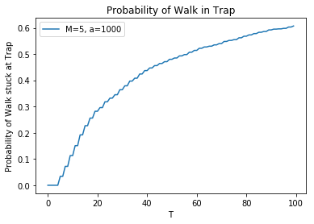

```python
probwalktrap(5,1000)
```

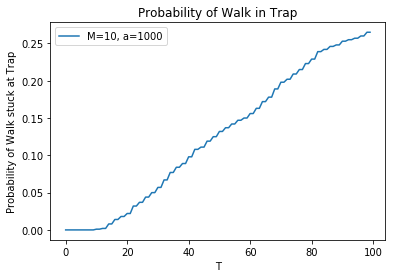

```python
probwalktrap(10,1000)
```

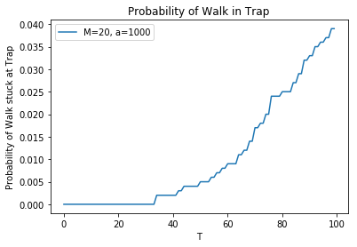

```python
probwalktrap(20,1000)
```

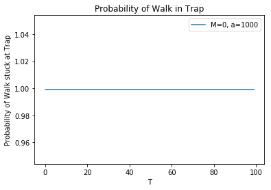

```python
probwalktrap(0,1000)
```

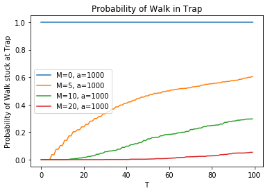

```python
probwalktrap(0,1000)
probwalktrap(5,1000)
probwalktrap(10,1000)
probwalktrap(20,1000)
```

Interpretaion:

As we can see, the probability of T getting stuck is 1 for trap at zero which is logical as all possible graphs would have there all 100 values stuck at 0 hence prob=1

We need to note two features of the graph: 1)As the distance of the trap from 0 increases the probability of a T getting stuck decreases 2)As the T increases the probaility increases

Explanation:

1) As the distance of the trap from origin increases the probability that the walk would reach there decreases. Now as the walk reaches there less, the probability of it getting stuck also decreases 2) Now in case the walk does reach the trap, then as the T increase the walk still remains at the trap. So for all the cases when the trap reaches Tsmall, the Tlarge gets incremented. But there are cases when the walk larger number of steps to reach the trap hence Tsmall doesnt get incremented but Tlarge gets the increment. Hence as T increases the probability i ncreases

Notice:

The probability of graph getting stuck is 0 for all T less than the distance of the trap from 0 as even if we get all +1, we cannot get to the trap as +T<dist